# Machine Learning Assignment

Shashi Mauli Tripathi

Sunday, December 27, 2015

## Background

Using devices such as Jawbone Up, Nike FuelBand, and Fitbit it is now possible to collect a large amount of data about personal activity relatively inexpensively. These type of devices are part of the quantified self movement - a group of enthusiasts who take measurements about themselves regularly to improve their health, to find patterns in their behavior, or because they are tech geeks. One thing that people regularly do is quantify how much of a particular activity they do, but they rarely quantify how well they do it. In this project, our goal will be to use data from accelerometers on the belt, forearm, arm, and dumbell of 6 participants. They were asked to perform barbell lifts correctly and incorrectly in 5 different ways. More information is available from the website here: [Human Activity Recognition](http://groupware.les.inf.puc-rio.br/har) (see the section on the Weight Lifting Exercise Dataset).

## Loading Packages

```r
library(caret)
```

```r
library(ggplot2)
library(rattle)
library(rpart)
library(rpart.plot)
library(corrplot)
```

## Data

Downloading and reading train and test datasets

```r
setwd("E:/shashi mauli/d drive/Shashi Documents/Shashi Mauli/Coursera/08_Practical_Machine_Learning/Project Assignemnt/Submission/")

## set.internet(TRUE)

## Downloading training data

## download.file("https://d396qusza40orc.cloudfront.net/predmachlearn/pml-training.csv", destfile = "./pml-training.csv")

## Downloading testing data

## download.file("https://d396qusza40orc.cloudfront.net/predmachlearn/pml-testing.csv", destfile = "./pml-testing.csv")

## Reading Training data
training <- read.csv("./pml-training.csv", na.strings = c("", "NA", "NULL"))

dim(training)
```

```
## [1] 19622   160
```

```r
## Reading testing data
testing <- read.csv("./pml-testing.csv", na.strings = c("", "NA", "NULL"))

dim(testing)
```

```
## [1]  20 160
```

## Data Preprocessing

We will Clean the data first before we start building models for prediction.

```r
## Removing identifier variables
rmID <- c('X', 'user_name', 'raw_timestamp_part_1', 'raw_timestamp_part_2','cvtd_timestamp', 'new_window', 'num_window')

training_rmID <- training[ , -which(names(training) %in% rmID)]

dim(training_rmID)
```

```
## [1] 19622   153
```

```r
## Removing variables with NA values
training_rmNA <- training_rmID[ , colSums(is.na(training_rmID)) == 0]

dim(training_rmNA)
```

```
## [1] 19622    53
```

Now we will remove variables which does not contain any information, i.e., have near zero variability

```r
nsv <- nearZeroVar(training_rmNA[sapply(training_rmNA, is.numeric)], saveMetrics = TRUE)

training_nonZeroVar <- training_rmNA[ , nsv$nzv == 0]
dim(training_nonZeroVar)
```

```
## [1] 19622    53
```

We will now look for variables which are highly correlated and delete them from the database

```r
## Computing correlation matrix for numeric variables

corrMatrix <- cor(na.omit(training_nonZeroVar[sapply(training_nonZeroVar, is.numeric)]))

dim(corrMatrix)
```

```
## [1] 52 52
```

[figure not shown]

```r
corrplot.mixed(corrMatrix)
```

```r
## Removing variables which have high correlation

rm_Cor <- findCorrelation(corrMatrix, cutoff = .90, verbose = FALSE)

training_rmCor <- training_nonZeroVar[ , -rm_Cor]
dim(training_rmCor)
```

```
## [1] 19622    46
```

The final dataset is ready. We will now split the data in 2 parts-  
1. train - to build the model  
2. test - to check for accuracy of the model

## Splitting Data

```r
set.seed(334853)
prt <- createDataPartition(training_rmCor$classe, p=0.70, list = FALSE)
trn <- training_rmCor[prt , ]
tst <- training_rmCor[-prt , ]
dim(trn) ; dim(tst)
```

```
## [1] 13737    46
```

```
## [1] 5885   46
```

## Data Analysis

We will first run “rpart” and check for model accuracy on test data.

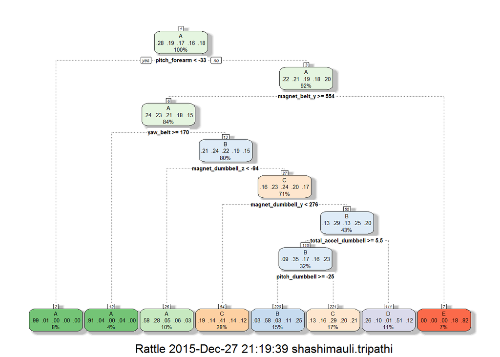

```r
set.seed(12345)
modFit <- train(classe ~. , data = trn, method = "rpart")
predicted <- predict(modFit, tst, type = "raw")
correctClass <- sum(ifelse(predicted == tst$classe,1,0))
CorrectClassification <- correctClass/nrow(tst)

fancyRpartPlot(modFit$finalModel)
```

The model accuracy using “rpart” is 0.53662

0.53662 is not very accurate. We will now try “random forest”

```r
set.seed(12345)
modFit <- train(classe ~. , data = trn, method = "rf")
predicted <- predict(modFit, tst, type = "raw")
correctClass <- sum(ifelse(predicted == tst$classe,1,0))
CorrectClassification <- correctClass/nrow(tst)
summary(modFit)
```

```
##                 Length Class      Mode
## call                4  -none-     call
## type                1  -none-     character
## predicted       13737  factor     numeric
## err.rate         3000  -none-     numeric
## confusion          30  -none-     numeric
## votes           68685  matrix     numeric
## oob.times       13737  -none-     numeric
## classes             5  -none-     character
## importance         45  -none-     numeric
## importanceSD        0  -none-     NULL
## localImportance     0  -none-     NULL
## proximity           0  -none-     NULL
## ntree               1  -none-     numeric
## mtry                1  -none-     numeric
## forest             14  -none-     list
## y               13737  factor     numeric
## test                0  -none-     NULL
## inbag               0  -none-     NULL
## xNames             45  -none-     character
## problemType         1  -none-     character
## tuneValue           1  data.frame list
## obsLevels           5  -none-     character
```

0.99218 is a very good estimate.

## Conclusion

We can now predict the test data with random forest model.

```r
prediction <- predict(modFit, testing, type = "raw")
prediction
```

```
##  [1] B A B A A E D B A A B C B A E E A B B B
## Levels: A B C D E
```

We will now submit these answers to the website.